# xplain_questionnaire

## 1.

```python
from bs4 import BeautifulSoup
import requests
from collections import Counter
import matplotlib.pyplot as plt
import datetime
import plotly
from IPython.display import Image
from dateutil.parser import parse
```

Αφού γίνει η φόρτωση των βιβλιοθηκών, χρησιμοποιούμε την βιβλιοθήκη BeautifulSoup, για να κάνουμε εξαγωγή των HTML στοιχείων που θέλουμε, παρακάτω εξάγουμε τα ποστ, το όνομα του μέλους που έκανε το αντίστοιχο πόστ, την ώρα και την ημερομηνια που έγινε το αντίστοιχο ποστ. Τα αποτελέσματα της εξαγωγής αυτής καταχωρούνται σε λίστες. Για να βρόυμε τις ζητούμενες πληροφορίες έγινε έλεγχος των HTML στοιχείων της σελίδας. Η συνάρτηση *find_all* της βιβλιοθήκης μας βοηθάει να βρούμε τους κόμβους (HTML nodes) με τα αντίστοιχα attributes. Παρακάτω παρατίθενται διαγράμματα που προέκυψαν από την ανάλυση που πραγματοποιήθηκε. Για την δημιουργία των διαγραμμάτων χρησιμοποιήθηκε η βιβλιοθήκη **matplotlib** , και για το interactive διάγραμμα η βιβλιόθήκη **plotly** της Python. Ο κώδικας των ερωτημάτων είναι γραμμένος σε **Python 3** .

```python
url1 = requests.get("https://www.adslgr.com/forum/threads/6588-Seti-home-Greece-United")
url2 = requests.get("https://www.adslgr.com/forum/threads/6588-Seti-home-Greece-United/page2")
```

```python
soup = BeautifulSoup(url1.text,"lxml")
```

```python
user_names = []
for link in soup.find_all("a",{"class" : "username offline popupctrl"}):
    user_names.append(link.strong.text)
```

```python
user_post = []
for link in soup.find_all("div",{"class" : "postrow"}):
    user_post.append(link.text)
```

```python
posted_date_time = []
for link in soup.find_all("span",{"class" : "date"}):
    posted_date_time.append(link.text.replace('\xa0', ' '))
```

```python
urls_per_post = []
for link in soup.find_all('blockquote',{"class" : "username_container"}):
    if link.a == None:
        urls_per_post.append([])
    else:
        temp = []
        for item in link.find_all("a"):
            temp.append(item['href'])
        urls_per_post.append(temp)
```

```python
soup2 = BeautifulSoup(url2.text,"lxml")
```

```python
for link in soup2.find_all("a",{"class" : "username offline popupctrl"}):
    user_names.append(link.strong.text)
```

```python
for link in soup2.find_all("div",{"class" : "postrow"}):
    user_post.append(link.text)
```

```python
for link in soup2.find_all("span",{"class" : "date"}):
    posted_date_time.append(link.text.replace('\xa0', ' '))
```

```python
for link in soup2.find_all('blockquote',{"class" : "postcontent restore"}):
    if link.a == None:
        urls_per_post.append([])
    else:
        temp = []
        for item in link.find_all("a"):
            temp.append(item['href'])
        urls_per_post.append(temp)
```

```python
dates = [k[0:k.find(',')] for k in posted_date_time]
count_dates = Counter(dates)
```

```python
dates = list(count_dates.keys())
dates = [parse(x).strftime('%d/%m/%Y') for x in dates]
dates = sorted(dates, key=lambda x: datetime.datetime.strptime(x, '%d/%m/%Y'),reverse=False)
```

Το παρακάτω διάγραμμα που προκύπτει είναι ένα barchart το οποίο υποδεικνύει το πλήθος των ποστ που έγιναν τις παρακάτω ημερομηνίες που βρίσκονται στον άξονα των χ. Πιο συγκεκριμένα είναι οι ημερομηνίες όλων των ποστ που έγιναν στο φόρουμ.

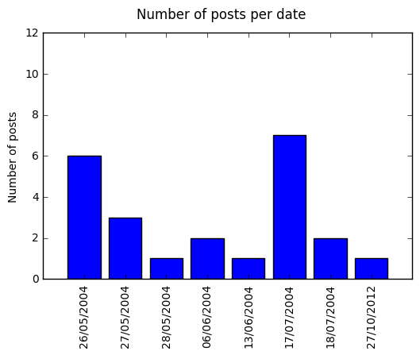

```python
plt.bar(range(len(count_dates)), count_dates.values(), align="center")
plt.xticks(range(len(count_dates)), dates,rotation='vertical')
plt.suptitle('Number of posts per date', fontsize=12)
plt.style.use('ggplot')
plt.ylabel('Number of posts')
plt.ylim((0,12))
plt.show()
```

```python
import plotly.plotly as py
import plotly.graph_objs as go
from plotly.offline import download_plotlyjs, init_notebook_mode, plot, iplot
init_notebook_mode(connected=True)
number_of_posts_per_user = Counter(user_names)
data = [go.Bar(
            y=list(number_of_posts_per_user.keys()),
            x=list(number_of_posts_per_user.values()),
            orientation = 'h'
)]
layout = go.Layout(
    title='Number of posts per user',
    xaxis=dict(
        title='Number of posts',
        titlefont=dict(
            family='Courier New, monospace',
            size=18,
            color='#7f7f7f'
        )
    ),
    yaxis=dict(

        titlefont=dict(
            family='Courier New, monospace',
            size=18,
            color='#7f7f7f'
        )
    )
)
iplot(go.Figure(data=data,layout=layout))
```

[interactive chart not shown]

Το παρακάτω διάγραμμα είναι και αυτό ένα barchart το οποίο μας δείχνει πόσοι χρήστες έχουν τον ίδιο αριθμό πόστ, από τα πόστ που έχουν υποβλιθεί στο φόρουμ.

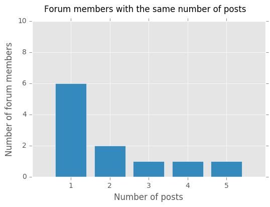

```python
out_degree = Counter(number_of_posts_per_user.values())
plt.bar(range(len(out_degree)), out_degree.values(), align="center")
plt.xticks(range(len(out_degree)), list(out_degree.keys()))
plt.suptitle('Forum members with the same number of posts', fontsize=12)
plt.xlabel('Number of posts')
plt.ylabel('Number of forum members')
plt.style.use('ggplot')
plt.ylim((0,10))
plt.show()
```

## 2.

Για να υπάρχει η δυνατότητα, τα παραπάνω να γίνουν για παραπάνω foroum, πρέπει αρχικά να ελέγξουμε τον HTML κώδικα των αντίστοιχων σελίδων από τις οποίες θέλουμε να εξάγουμε δεδομένα, και κάνοντας χρήση XPath ή DOM selectors να πάρουμε τα αντίστοιχα δεδομένα που θέλουμε.

Ένας άλλος τρόπος είναι η χρήση Μηχανικής Μάθησης, δηλαδή να χρησιμοποιήσουμε ένα μοντέλο που εξάγει πληροφορία από πολλές ιστοσελίδες (φόρουμ, κτλπ), έχοντας ως δεδομένο ότι τα φόρουμ θα έχουν περίπου την ίδια μορφή στον HTML Κώδικα τους. Θα χρησιμοποιήσουμε λοιπόν ένα σύνολο σελίδων ως training set, από τις οποίες, θα εξάγουμε ΧPath, και attributes που , τα αντίστοιχα θέλουμε να εξάγουμε από τέστ δεδομένα, και εκπαιδεύοντας το μοντέλο, κάνοντας χρήση αλγορίθμων μηχανικής μάθησης, το μοντέλο μετα θα βρεί patterns, τα οποία θα τα χρησιμοποιήσει για να προβλεψει τα αντίστοιχα attributes στα τεστ δεδομένα.

## 3.

1. Στον φάκελο του πρότζεκτ κάνουμε activate το virtual enviroment, η εκκίνηση γίνεται με την εντολή **activate**, αντίστοιχα για την απενεργοποίηση χρησιμοποιείται η εντολή **deactivate**
2. Αφού γίνει η ενεργοποίηση του virtual enviroment, αναγράφεται δίπλα από το directory στο cmd η λέξη (flask) και πλεόν μπορούμε να τρέξουμε το script που θα δέχεται ως όρισμα ημενομηνια και ώρα, θα εμφανίζεται στο url http://127.0.0.1:5000/date, αντίστοιχα το κείμενο που θα δίνεται από τον χρήστη θα εμφανίζεται στο url http://127.0.0.1:5000/text, για όσο τρέχει το script test.py.

Ο κώδικας που χρησιμοποιήθηκε για τα παραπάνω, είναι το αρχείο **test.py**, το οποίο επισυνάπτεται.

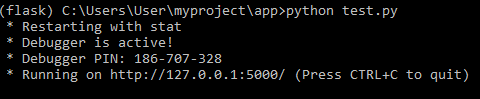

```python
Image(filename='1.png')
```

[figure not shown]

```python
Image(filename='2.png')
```

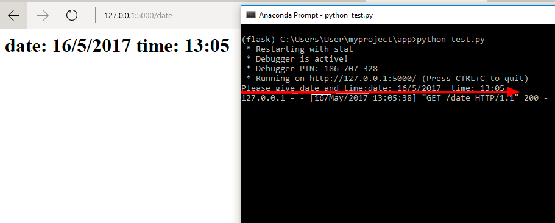

```python
Image(filename='3.png')
```

## 4.

**a.** Στην περίπτωση όπου κάθε post μπορεί να πάρει εώς m tags, και το m κυμαίνεται μεταξύ του 1< m < n/2, τότε μια ιδέα είναι η εξής, να μετατρέψουμε τα posts, se tfidf bag of words, στην ανάλυση των κειμένων θα έχουμε αφαιρέσει stopwords (χρήση της βιβλιοθήκης NLTK για να απορρίψουμε τα stopwords) και με την χρήση της βιβλιοθήκης sklearn μπορούμε να κάνουμε feature extraction, TfidfVectorizer για tfiidf bag of words, και επιλέγουμε για κάθε post τα features (λέξεις) με τα μεγαλύτερα tfidf βάρη για tags, επειδή έχουμε τον περιορισμό να είναι τα τα tags μέχρι n/2, επιλεγουμε τα πρώτα n/2 features με τα μεγαλύτερα tfidf βάρη.

**b.** Aν τα ποστ στα οποία έχουν ήδη δοθεί tags, μπορούν να χρησιμοποιηθούν σαν training set, (50n είναι τα ποστ που θα αποτελέσουν το σύνολο εκπαίδευσης), έτσι λοιπόν χρησιμοποιώντας την βιβλιοθήκη sklearn μπορόύμε να μετατρέψουμε σε bag of words τα ποστ του συνόλου εκπαίδευσης, αφαιρούμε stopwords, δηλαδή κάνουμε feature extraction στο training set, όμοια και στο τεστ σετ (υπόλοιπα πόστ στα οποία δεν έχουν δοθεί tags). Κάθε πόστ δηλαδή αναπαρίσταται από τα αντίστοιχα features του, μια ιδέα είναι να εφαρμόσομου Jaccard Similarity για κάθε ποστ χωρις tag στα ποστ που έχουν tags, και τα πoστ από το σύνολο εκπαίδευσης που μοιάζουν περισσότερο΄ή το ποστ που μοίαζει περισσότερο με το αντίστοιχο ποστ από το τεστ σετ να δόσει τα tags του στο ποστ του τεστ σετ. H ιδέα αυτή μπορεί να υλοποιηθεί με cosine similarity ή με χρήση του k nearest neighboor χρησιμοποιώντας ευκλειδειες αποστάσεις μεταξύ των features του ποστ χωρις tags με τα features των ποστ με ταγκς.

**c.** Όταν το μέσο πλήθος των λέξεων ανά ποστ είναι 10, μπορούμε να εφαρμόσουμε την ιδέα που δόθηκε στo a. ερώτημα, αποτελεί γρήγορη τεχνική.

**d.** Στην περίπτωση των ποστ με εικόνες αυτό που μπορούμε να κάνουμε είναι να έχουμε ήδη ένα σύνολο εικόνων σαν training set, για παράδειγμα εικόνες με ζώα, κάθε εικόνα είναι μια δυαδική αναπαράσταση, έτσι λοιπόν και για κάθε πόστ για το οποίο θέλουμε να βρούμε tags, αν το ποστ περιέχει εικόνα εφαρμόζουμε μείωση διάστασης στην εικόνα κάνοντας χρήση PCA (Principal Components Analysis), και εφαρμόζουμε ΚΝΝ(Κ Νearest Neighboor) μεταξύ των εικονών των ποστ και των εικόνων που έχουμε σαν training σετ, αν μια εικόνα ενός ποστ είναι 'κοντά' σύμφωνα με τον ΚΝΝ, με μια εικόνα του train set που αναπαριστά σκύλους (έχει δηλ αντίστοιχο label), τότε δίνουμε το αντίστοιχο label και στην εικόνα του πόστ. Με αυτόν τον τρόπο μπορούμε να βγάλουμε tags από εικόνες.

## 5.

Για να αναγνωρίσουμε αν μια εικόνα από τις Ν εικόνες βρίσκεται μέσα στο βίντεο, αυτό που μπορούμε να κάνουμε είναι να πάρουμε frames του βίντεο, να εφαρμόσουμε μείωση διάστασης (χρήση PCA) ή επιλογή χαρακτηριστικών στα frames, όμοια και στις Ν φωτογραφίες και εφαρμόζωντας ΚΝΝ,και για μέτρο σύγκρισης την ευκλείδια απόσταση, μπορούμε να αναγνωρίσουμε πότε μια εικόνα είναι σε ένα frame του βίντεο. Δηλαδή πιο συγκεκριμένα αν μια εικόνα και ένα video frame έχουν κοντινή απόσταση σύμφωνα με τον αλγόριθμο ΚΝΝ τότε μπορούμε να πούμε ότι η εικόνα αυτή είναι μέσα στο αντίστοιχο frame.